# Risk Factor Analysis

## Outcome Variable

**Outcome Variable:** whz

## Predictor Variables

**Intervention Variable:** mbmi

**Adjustment Set:**

- arm
- W_mage
- W_fage
- meducyrs
- feducyrs
- single
- brthmon
- W_gagebrth
- W_birthwt
- W_birthlen
- vagbrth
- delta_W_mage
- delta_W_fage
- delta_meducyrs
- delta_feducyrs
- delta_single
- delta_brthmon
- delta_W_gagebrth
- delta_W_birthwt
- delta_W_birthlen
- delta_vagbrth

## Stratifying Variables

The analysis was stratified on these variable(s):

- agecat
- studyid
- country

## Data Summary

| agecat | studyid | country | mbmi | n_cell | n |
| --- | --- | --- | --- | --- | --- |
| 6 months | ki0047075b-MAL-ED | BANGLADESH | Normal weight | 209 | 241 |
| 6 months | ki0047075b-MAL-ED | BANGLADESH | Underweight | 32 | 241 |
| 6 months | ki0047075b-MAL-ED | BRAZIL | Normal weight | 199 | 208 |
| 6 months | ki0047075b-MAL-ED | BRAZIL | Underweight | 9 | 208 |
| 6 months | ki0047075b-MAL-ED | INDIA | Normal weight | 186 | 235 |
| 6 months | ki0047075b-MAL-ED | INDIA | Underweight | 49 | 235 |
| 6 months | ki0047075b-MAL-ED | NEPAL | Normal weight | 236 | 236 |
| 6 months | ki0047075b-MAL-ED | NEPAL | Underweight | 0 | 236 |
| 6 months | ki0047075b-MAL-ED | PERU | Normal weight | 267 | 272 |
| 6 months | ki0047075b-MAL-ED | PERU | Underweight | 5 | 272 |
| 6 months | ki0047075b-MAL-ED | SOUTH AFRICA | Normal weight | 242 | 249 |
| 6 months | ki0047075b-MAL-ED | SOUTH AFRICA | Underweight | 7 | 249 |
| 6 months | ki0047075b-MAL-ED | TANZANIA, UNITED REPUBLIC OF | Normal weight | 233 | 247 |
| 6 months | ki0047075b-MAL-ED | TANZANIA, UNITED REPUBLIC OF | Underweight | 14 | 247 |
| 6 months | ki1000304b-SAS-CompFeed | INDIA | Normal weight | 921 | 1225 |
| 6 months | ki1000304b-SAS-CompFeed | INDIA | Underweight | 304 | 1225 |
| 6 months | ki1017093-NIH-Birth | BANGLADESH | Normal weight | 443 | 536 |
| 6 months | ki1017093-NIH-Birth | BANGLADESH | Underweight | 93 | 536 |
| 6 months | ki1017093b-PROVIDE | BANGLADESH | Normal weight | 480 | 581 |
| 6 months | ki1017093b-PROVIDE | BANGLADESH | Underweight | 101 | 581 |
| 6 months | ki1017093c-NIH-Crypto | BANGLADESH | Normal weight | 648 | 715 |
| 6 months | ki1017093c-NIH-Crypto | BANGLADESH | Underweight | 67 | 715 |
| 6 months | ki1066203-TanzaniaChild2 | TANZANIA, UNITED REPUBLIC OF | Normal weight | 1949 | 1982 |
| 6 months | ki1066203-TanzaniaChild2 | TANZANIA, UNITED REPUBLIC OF | Underweight | 33 | 1982 |
| 6 months | ki1119695-PROBIT | BELARUS | Normal weight | 12519 | 13024 |
| 6 months | ki1119695-PROBIT | BELARUS | Underweight | 505 | 13024 |
| 6 months | ki1126311-ZVITAMBO | ZIMBABWE | Normal weight | 6726 | 7087 |
| 6 months | ki1126311-ZVITAMBO | ZIMBABWE | Underweight | 361 | 7087 |
| 6 months | ki1148112-LCNI-5 | MALAWI | Normal weight | 691 | 836 |
| 6 months | ki1148112-LCNI-5 | MALAWI | Underweight | 145 | 836 |
| 24 months | ki0047075b-MAL-ED | BANGLADESH | Normal weight | 183 | 212 |
| 24 months | ki0047075b-MAL-ED | BANGLADESH | Underweight | 29 | 212 |
| 24 months | ki0047075b-MAL-ED | BRAZIL | Normal weight | 162 | 168 |
| 24 months | ki0047075b-MAL-ED | BRAZIL | Underweight | 6 | 168 |
| 24 months | ki0047075b-MAL-ED | INDIA | Normal weight | 180 | 226 |
| 24 months | ki0047075b-MAL-ED | INDIA | Underweight | 46 | 226 |
| 24 months | ki0047075b-MAL-ED | NEPAL | Normal weight | 228 | 228 |
| 24 months | ki0047075b-MAL-ED | NEPAL | Underweight | 0 | 228 |
| 24 months | ki0047075b-MAL-ED | PERU | Normal weight | 197 | 201 |
| 24 months | ki0047075b-MAL-ED | PERU | Underweight | 4 | 201 |
| 24 months | ki0047075b-MAL-ED | SOUTH AFRICA | Normal weight | 227 | 234 |
| 24 months | ki0047075b-MAL-ED | SOUTH AFRICA | Underweight | 7 | 234 |
| 24 months | ki0047075b-MAL-ED | TANZANIA, UNITED REPUBLIC OF | Normal weight | 203 | 214 |
| 24 months | ki0047075b-MAL-ED | TANZANIA, UNITED REPUBLIC OF | Underweight | 11 | 214 |
| 24 months | ki1017093-NIH-Birth | BANGLADESH | Normal weight | 348 | 428 |
| 24 months | ki1017093-NIH-Birth | BANGLADESH | Underweight | 80 | 428 |
| 24 months | ki1017093b-PROVIDE | BANGLADESH | Normal weight | 477 | 577 |
| 24 months | ki1017093b-PROVIDE | BANGLADESH | Underweight | 100 | 577 |
| 24 months | ki1017093c-NIH-Crypto | BANGLADESH | Normal weight | 471 | 514 |
| 24 months | ki1017093c-NIH-Crypto | BANGLADESH | Underweight | 43 | 514 |
| 24 months | ki1066203-TanzaniaChild2 | TANZANIA, UNITED REPUBLIC OF | Normal weight | 6 | 6 |
| 24 months | ki1066203-TanzaniaChild2 | TANZANIA, UNITED REPUBLIC OF | Underweight | 0 | 6 |
| 24 months | ki1119695-PROBIT | BELARUS | Normal weight | 3800 | 3941 |
| 24 months | ki1119695-PROBIT | BELARUS | Underweight | 141 | 3941 |
| 24 months | ki1126311-ZVITAMBO | ZIMBABWE | Normal weight | 334 | 359 |
| 24 months | ki1126311-ZVITAMBO | ZIMBABWE | Underweight | 25 | 359 |
| 24 months | ki1148112-LCNI-5 | MALAWI | Normal weight | 467 | 561 |
| 24 months | ki1148112-LCNI-5 | MALAWI | Underweight | 94 | 561 |

The following strata were considered:

- agecat: 24 months, studyid: ki0047075b-MAL-ED, country: BANGLADESH
- agecat: 24 months, studyid: ki0047075b-MAL-ED, country: BRAZIL
- agecat: 24 months, studyid: ki0047075b-MAL-ED, country: INDIA
- agecat: 24 months, studyid: ki0047075b-MAL-ED, country: NEPAL
- agecat: 24 months, studyid: ki0047075b-MAL-ED, country: PERU
- agecat: 24 months, studyid: ki0047075b-MAL-ED, country: SOUTH AFRICA
- agecat: 24 months, studyid: ki0047075b-MAL-ED, country: TANZANIA, UNITED REPUBLIC OF
- agecat: 24 months, studyid: ki1017093-NIH-Birth, country: BANGLADESH
- agecat: 24 months, studyid: ki1017093b-PROVIDE, country: BANGLADESH
- agecat: 24 months, studyid: ki1017093c-NIH-Crypto, country: BANGLADESH
- agecat: 24 months, studyid: ki1066203-TanzaniaChild2, country: TANZANIA, UNITED REPUBLIC OF
- agecat: 24 months, studyid: ki1119695-PROBIT, country: BELARUS
- agecat: 24 months, studyid: ki1126311-ZVITAMBO, country: ZIMBABWE
- agecat: 24 months, studyid: ki1148112-LCNI-5, country: MALAWI
- agecat: 6 months, studyid: ki0047075b-MAL-ED, country: BANGLADESH
- agecat: 6 months, studyid: ki0047075b-MAL-ED, country: BRAZIL
- agecat: 6 months, studyid: ki0047075b-MAL-ED, country: INDIA
- agecat: 6 months, studyid: ki0047075b-MAL-ED, country: NEPAL
- agecat: 6 months, studyid: ki0047075b-MAL-ED, country: PERU
- agecat: 6 months, studyid: ki0047075b-MAL-ED, country: SOUTH AFRICA
- agecat: 6 months, studyid: ki0047075b-MAL-ED, country: TANZANIA, UNITED REPUBLIC OF
- agecat: 6 months, studyid: ki1000304b-SAS-CompFeed, country: INDIA
- agecat: 6 months, studyid: ki1017093-NIH-Birth, country: BANGLADESH
- agecat: 6 months, studyid: ki1017093b-PROVIDE, country: BANGLADESH
- agecat: 6 months, studyid: ki1017093c-NIH-Crypto, country: BANGLADESH
- agecat: 6 months, studyid: ki1066203-TanzaniaChild2, country: TANZANIA, UNITED REPUBLIC OF
- agecat: 6 months, studyid: ki1119695-PROBIT, country: BELARUS
- agecat: 6 months, studyid: ki1126311-ZVITAMBO, country: ZIMBABWE
- agecat: 6 months, studyid: ki1148112-LCNI-5, country: MALAWI

### Dropped Strata

Some strata were dropped due to rare outcomes:

- agecat: 6 months, studyid: ki0047075b-MAL-ED, country: NEPAL
- agecat: 24 months, studyid: ki0047075b-MAL-ED, country: NEPAL
- agecat: 24 months, studyid: ki0047075b-MAL-ED, country: PERU
- agecat: 24 months, studyid: ki1066203-TanzaniaChild2, country: TANZANIA, UNITED REPUBLIC OF

## Methods Detail

We’re interested in the causal parameters $E[Y_a]$ for all values of $a \in \mathcal{A}$. These parameters represent the mean outcome if, possibly contrary to fact, we intervened to set all units to have $A=a$. Under the randomization and positivity assumptions, these are identified by the statistical parameters $\psi_a=E_W[E_{Y|A,W}(Y|A=a,W)]$. In addition, we’re interested in the mean of $Y$, $E[Y]$ under no intervention (the observed mean). We will estimate these parameters by using SuperLearner to fit the relevant likelihood factors – $E_{Y|A,W}(Y|A=a,W)$ and $p(A=a|W)$, and then updating our likelihood fit using a joint TMLE.

For unadjusted analyses ($W=\{\}$), initial likelihoods were estimated using Lrnr_glm to estimate the simple $E(Y|A)$ and Lrnr_mean to estimate $p(A)$. For adjusted analyses, a small library containing Lrnr_glmnet, Lrnr_xgboost, and Lrnr_mean was used.

Having estimated these parameters, we will then use the delta method to estimate relative risks and attributable risks relative to a prespecified baseline level of $A$.

# Results Detail

## Results Plots

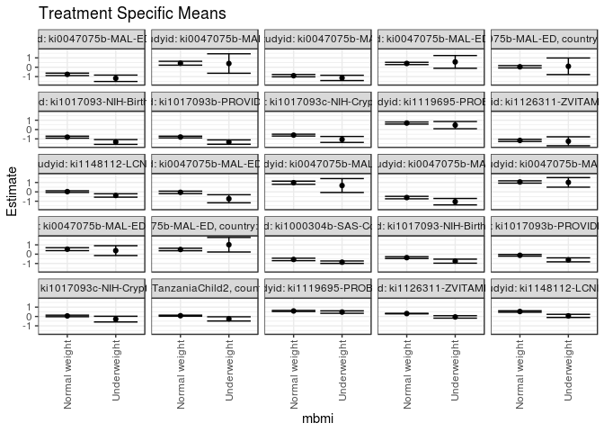

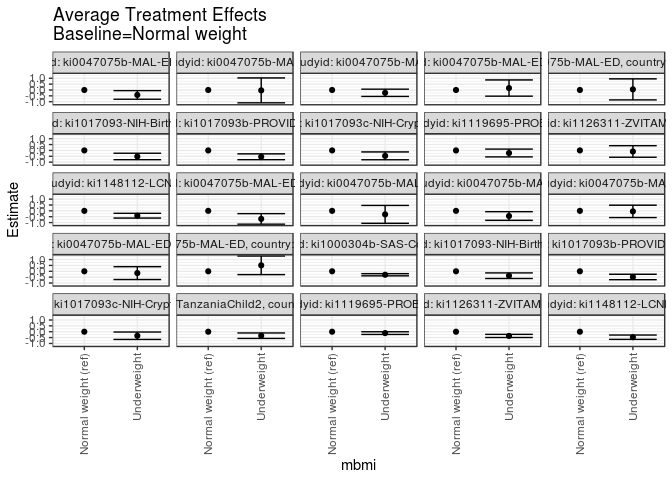

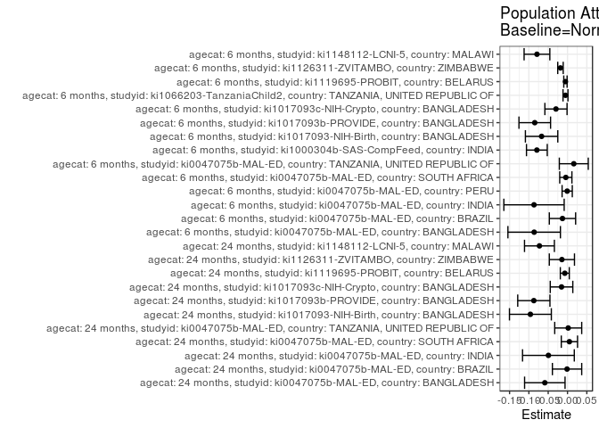

## Results Table

### Parameter: TSM

| agecat | studyid | country | intervention_level | baseline_level | estimate | ci_lower | ci_upper |
| --- | --- | --- | --- | --- | --- | --- | --- |
| 6 months | ki0047075b-MAL-ED | BANGLADESH | Normal weight | NA | -0.0534814 | -0.1822894 | 0.0753265 |
| 6 months | ki0047075b-MAL-ED | BANGLADESH | Underweight | NA | -0.7399766 | -1.1714675 | -0.3084856 |
| 6 months | ki0047075b-MAL-ED | BRAZIL | Normal weight | NA | 0.9775209 | 0.8091090 | 1.1459329 |
| 6 months | ki0047075b-MAL-ED | BRAZIL | Underweight | NA | 0.6764815 | -0.0674862 | 1.4204491 |
| 6 months | ki0047075b-MAL-ED | INDIA | Normal weight | NA | -0.6120965 | -0.7435028 | -0.4806903 |
| 6 months | ki0047075b-MAL-ED | INDIA | Underweight | NA | -1.0529959 | -1.3972960 | -0.7086958 |
| 6 months | ki0047075b-MAL-ED | PERU | Normal weight | NA | 1.0571910 | 0.9326684 | 1.1817136 |
| 6 months | ki0047075b-MAL-ED | PERU | Underweight | NA | 1.0130000 | 0.5008674 | 1.5251326 |
| 6 months | ki0047075b-MAL-ED | SOUTH AFRICA | Normal weight | NA | 0.5333953 | 0.3757046 | 0.6910860 |
| 6 months | ki0047075b-MAL-ED | SOUTH AFRICA | Underweight | NA | 0.3785714 | -0.1478585 | 0.9050014 |
| 6 months | ki0047075b-MAL-ED | TANZANIA, UNITED REPUBLIC OF | Normal weight | NA | 0.5007614 | 0.3654893 | 0.6360335 |
| 6 months | ki0047075b-MAL-ED | TANZANIA, UNITED REPUBLIC OF | Underweight | NA | 1.0101110 | 0.2315751 | 1.7886470 |
| 6 months | ki1000304b-SAS-CompFeed | INDIA | Normal weight | NA | -0.5647696 | -0.6966524 | -0.4328869 |
| 6 months | ki1000304b-SAS-CompFeed | INDIA | Underweight | NA | -0.8594544 | -0.9885709 | -0.7303378 |
| 6 months | ki1017093-NIH-Birth | BANGLADESH | Normal weight | NA | -0.3718321 | -0.4692420 | -0.2744221 |
| 6 months | ki1017093-NIH-Birth | BANGLADESH | Underweight | NA | -0.7487627 | -0.9650573 | -0.5324682 |
| 6 months | ki1017093b-PROVIDE | BANGLADESH | Normal weight | NA | -0.1232178 | -0.2143951 | -0.0320405 |
| 6 months | ki1017093b-PROVIDE | BANGLADESH | Underweight | NA | -0.6096226 | -0.8227104 | -0.3965348 |
| 6 months | ki1017093c-NIH-Crypto | BANGLADESH | Normal weight | NA | 0.0596155 | -0.0224600 | 0.1416910 |
| 6 months | ki1017093c-NIH-Crypto | BANGLADESH | Underweight | NA | -0.2834258 | -0.5887304 | 0.0218788 |
| 6 months | ki1066203-TanzaniaChild2 | TANZANIA, UNITED REPUBLIC OF | Normal weight | NA | 0.0827328 | 0.0283500 | 0.1371155 |
| 6 months | ki1066203-TanzaniaChild2 | TANZANIA, UNITED REPUBLIC OF | Underweight | NA | -0.2581827 | -0.4846449 | -0.0317205 |
| 6 months | ki1119695-PROBIT | BELARUS | Normal weight | NA | 0.5883492 | 0.5303160 | 0.6463825 |
| 6 months | ki1119695-PROBIT | BELARUS | Underweight | NA | 0.4708169 | 0.3419782 | 0.5996557 |
| 6 months | ki1126311-ZVITAMBO | ZIMBABWE | Normal weight | NA | 0.3110187 | 0.2824901 | 0.3395473 |
| 6 months | ki1126311-ZVITAMBO | ZIMBABWE | Underweight | NA | -0.0481277 | -0.1787468 | 0.0824914 |
| 6 months | ki1148112-LCNI-5 | MALAWI | Normal weight | NA | 0.5305992 | 0.4522807 | 0.6089177 |
| 6 months | ki1148112-LCNI-5 | MALAWI | Underweight | NA | 0.0610602 | -0.1069899 | 0.2291103 |
| 24 months | ki0047075b-MAL-ED | BANGLADESH | Normal weight | NA | -0.7620906 | -0.8924289 | -0.6317523 |
| 24 months | ki0047075b-MAL-ED | BANGLADESH | Underweight | NA | -1.1837624 | -1.5264566 | -0.8410683 |
| 24 months | ki0047075b-MAL-ED | BRAZIL | Normal weight | NA | 0.4294444 | 0.2224555 | 0.6364334 |
| 24 months | ki0047075b-MAL-ED | BRAZIL | Underweight | NA | 0.3966667 | -0.6451983 | 1.4385316 |
| 24 months | ki0047075b-MAL-ED | INDIA | Normal weight | NA | -0.9031514 | -1.0277473 | -0.7785556 |
| 24 months | ki0047075b-MAL-ED | INDIA | Underweight | NA | -1.1429662 | -1.4273964 | -0.8585360 |
| 24 months | ki0047075b-MAL-ED | SOUTH AFRICA | Normal weight | NA | 0.4046696 | 0.2835400 | 0.5257992 |
| 24 months | ki0047075b-MAL-ED | SOUTH AFRICA | Underweight | NA | 0.5700000 | -0.1123856 | 1.2523856 |
| 24 months | ki0047075b-MAL-ED | TANZANIA, UNITED REPUBLIC OF | Normal weight | NA | 0.0482414 | -0.0788602 | 0.1753431 |
| 24 months | ki0047075b-MAL-ED | TANZANIA, UNITED REPUBLIC OF | Underweight | NA | 0.1010337 | -0.7858161 | 0.9878835 |
| 24 months | ki1017093-NIH-Birth | BANGLADESH | Normal weight | NA | -0.8155166 | -0.9189175 | -0.7121157 |
| 24 months | ki1017093-NIH-Birth | BANGLADESH | Underweight | NA | -1.3310240 | -1.5881242 | -1.0739238 |
| 24 months | ki1017093b-PROVIDE | BANGLADESH | Normal weight | NA | -0.7993240 | -0.8894744 | -0.7091736 |
| 24 months | ki1017093b-PROVIDE | BANGLADESH | Underweight | NA | -1.3416723 | -1.5729112 | -1.1104333 |
| 24 months | ki1017093c-NIH-Crypto | BANGLADESH | Normal weight | NA | -0.5948715 | -0.6945479 | -0.4951950 |
| 24 months | ki1017093c-NIH-Crypto | BANGLADESH | Underweight | NA | -1.0585945 | -1.3771753 | -0.7400137 |
| 24 months | ki1119695-PROBIT | BELARUS | Normal weight | NA | 0.6939605 | 0.5840211 | 0.8038999 |
| 24 months | ki1119695-PROBIT | BELARUS | Underweight | NA | 0.4729149 | 0.0878209 | 0.8580089 |
| 24 months | ki1126311-ZVITAMBO | ZIMBABWE | Normal weight | NA | -1.1664687 | -1.2807099 | -1.0522274 |
| 24 months | ki1126311-ZVITAMBO | ZIMBABWE | Underweight | NA | -1.2554341 | -1.7341447 | -0.7767234 |
| 24 months | ki1148112-LCNI-5 | MALAWI | Normal weight | NA | 0.0256774 | -0.0642506 | 0.1156054 |
| 24 months | ki1148112-LCNI-5 | MALAWI | Underweight | NA | -0.3867685 | -0.5686481 | -0.2048890 |

### Parameter: E(Y)

| agecat | studyid | country | intervention_level | baseline_level | estimate | ci_lower | ci_upper |
| --- | --- | --- | --- | --- | --- | --- | --- |
| 6 months | ki0047075b-MAL-ED | BANGLADESH | NA | NA | -0.1397960 | -0.2688682 | -0.0107238 |
| 6 months | ki0047075b-MAL-ED | BRAZIL | NA | NA | 0.9644952 | 0.7999744 | 1.1290160 |
| 6 months | ki0047075b-MAL-ED | INDIA | NA | NA | -0.6987943 | -0.8241325 | -0.5734561 |
| 6 months | ki0047075b-MAL-ED | PERU | NA | NA | 1.0563787 | 0.9342938 | 1.1784635 |
| 6 months | ki0047075b-MAL-ED | SOUTH AFRICA | NA | NA | 0.5290428 | 0.3750394 | 0.6830463 |
| 6 months | ki0047075b-MAL-ED | TANZANIA, UNITED REPUBLIC OF | NA | NA | 0.5170513 | 0.3872178 | 0.6468847 |
| 6 months | ki1000304b-SAS-CompFeed | INDIA | NA | NA | -0.6441020 | -0.7710827 | -0.5171213 |
| 6 months | ki1017093-NIH-Birth | BANGLADESH | NA | NA | -0.4389101 | -0.5279432 | -0.3498771 |
| 6 months | ki1017093b-PROVIDE | BANGLADESH | NA | NA | -0.2079891 | -0.2925599 | -0.1234183 |
| 6 months | ki1017093c-NIH-Crypto | BANGLADESH | NA | NA | 0.0297622 | -0.0491685 | 0.1086930 |
| 6 months | ki1066203-TanzaniaChild2 | TANZANIA, UNITED REPUBLIC OF | NA | NA | 0.0775172 | 0.0241750 | 0.1308595 |
| 6 months | ki1119695-PROBIT | BELARUS | NA | NA | 0.5829956 | 0.5247249 | 0.6412663 |
| 6 months | ki1126311-ZVITAMBO | ZIMBABWE | NA | NA | 0.2928094 | 0.2648167 | 0.3208020 |
| 6 months | ki1148112-LCNI-5 | MALAWI | NA | NA | 0.4515431 | 0.3802415 | 0.5228446 |
| 24 months | ki0047075b-MAL-ED | BANGLADESH | NA | NA | -0.8208255 | -0.9429246 | -0.6987264 |
| 24 months | ki0047075b-MAL-ED | BRAZIL | NA | NA | 0.4282738 | 0.2252365 | 0.6313111 |
| 24 months | ki0047075b-MAL-ED | INDIA | NA | NA | -0.9525664 | -1.0684455 | -0.8366872 |
| 24 months | ki0047075b-MAL-ED | SOUTH AFRICA | NA | NA | 0.4096154 | 0.2902946 | 0.5289362 |
| 24 months | ki0047075b-MAL-ED | TANZANIA, UNITED REPUBLIC OF | NA | NA | 0.0500935 | -0.0748234 | 0.1750103 |
| 24 months | ki1017093-NIH-Birth | BANGLADESH | NA | NA | -0.9115790 | -1.0095022 | -0.8136559 |
| 24 months | ki1017093b-PROVIDE | BANGLADESH | NA | NA | -0.8864991 | -0.9695215 | -0.8034768 |
| 24 months | ki1017093c-NIH-Crypto | BANGLADESH | NA | NA | -0.6103502 | -0.7050157 | -0.5156847 |
| 24 months | ki1119695-PROBIT | BELARUS | NA | NA | 0.6869754 | 0.5725638 | 0.8013869 |
| 24 months | ki1126311-ZVITAMBO | ZIMBABWE | NA | NA | -1.1810028 | -1.2914599 | -1.0705456 |
| 24 months | ki1148112-LCNI-5 | MALAWI | NA | NA | -0.0469519 | -0.1290932 | 0.0351895 |

### Parameter: ATE

| agecat | studyid | country | intervention_level | baseline_level | estimate | ci_lower | ci_upper |
| --- | --- | --- | --- | --- | --- | --- | --- |
| 6 months | ki0047075b-MAL-ED | BANGLADESH | Normal weight | Normal weight | 0.0000000 | 0.0000000 | 0.0000000 |
| 6 months | ki0047075b-MAL-ED | BANGLADESH | Underweight | Normal weight | -0.6864952 | -1.1371030 | -0.2358873 |
| 6 months | ki0047075b-MAL-ED | BRAZIL | Normal weight | Normal weight | 0.0000000 | 0.0000000 | 0.0000000 |
| 6 months | ki0047075b-MAL-ED | BRAZIL | Underweight | Normal weight | -0.3010395 | -1.0638307 | 0.4617517 |
| 6 months | ki0047075b-MAL-ED | INDIA | Normal weight | Normal weight | 0.0000000 | 0.0000000 | 0.0000000 |
| 6 months | ki0047075b-MAL-ED | INDIA | Underweight | Normal weight | -0.4408993 | -0.8098432 | -0.0719555 |
| 6 months | ki0047075b-MAL-ED | PERU | Normal weight | Normal weight | 0.0000000 | 0.0000000 | 0.0000000 |
| 6 months | ki0047075b-MAL-ED | PERU | Underweight | Normal weight | -0.0441910 | -0.5712448 | 0.4828628 |
| 6 months | ki0047075b-MAL-ED | SOUTH AFRICA | Normal weight | Normal weight | 0.0000000 | 0.0000000 | 0.0000000 |
| 6 months | ki0047075b-MAL-ED | SOUTH AFRICA | Underweight | Normal weight | -0.1548239 | -0.7043645 | 0.3947167 |
| 6 months | ki0047075b-MAL-ED | TANZANIA, UNITED REPUBLIC OF | Normal weight | Normal weight | 0.0000000 | 0.0000000 | 0.0000000 |
| 6 months | ki0047075b-MAL-ED | TANZANIA, UNITED REPUBLIC OF | Underweight | Normal weight | 0.5093497 | -0.2830945 | 1.3017938 |
| 6 months | ki1000304b-SAS-CompFeed | INDIA | Normal weight | Normal weight | 0.0000000 | 0.0000000 | 0.0000000 |
| 6 months | ki1000304b-SAS-CompFeed | INDIA | Underweight | Normal weight | -0.2946847 | -0.3867869 | -0.2025826 |
| 6 months | ki1017093-NIH-Birth | BANGLADESH | Normal weight | Normal weight | 0.0000000 | 0.0000000 | 0.0000000 |
| 6 months | ki1017093-NIH-Birth | BANGLADESH | Underweight | Normal weight | -0.3769307 | -0.6149025 | -0.1389589 |
| 6 months | ki1017093b-PROVIDE | BANGLADESH | Normal weight | Normal weight | 0.0000000 | 0.0000000 | 0.0000000 |
| 6 months | ki1017093b-PROVIDE | BANGLADESH | Underweight | Normal weight | -0.4864048 | -0.7177477 | -0.2550620 |
| 6 months | ki1017093c-NIH-Crypto | BANGLADESH | Normal weight | Normal weight | 0.0000000 | 0.0000000 | 0.0000000 |
| 6 months | ki1017093c-NIH-Crypto | BANGLADESH | Underweight | Normal weight | -0.3430413 | -0.6590600 | -0.0270227 |
| 6 months | ki1066203-TanzaniaChild2 | TANZANIA, UNITED REPUBLIC OF | Normal weight | Normal weight | 0.0000000 | 0.0000000 | 0.0000000 |
| 6 months | ki1066203-TanzaniaChild2 | TANZANIA, UNITED REPUBLIC OF | Underweight | Normal weight | -0.3409154 | -0.5740014 | -0.1078295 |
| 6 months | ki1119695-PROBIT | BELARUS | Normal weight | Normal weight | 0.0000000 | 0.0000000 | 0.0000000 |
| 6 months | ki1119695-PROBIT | BELARUS | Underweight | Normal weight | -0.1175323 | -0.2304579 | -0.0046067 |
| 6 months | ki1126311-ZVITAMBO | ZIMBABWE | Normal weight | Normal weight | 0.0000000 | 0.0000000 | 0.0000000 |
| 6 months | ki1126311-ZVITAMBO | ZIMBABWE | Underweight | Normal weight | -0.3591464 | -0.4926226 | -0.2256701 |
| 6 months | ki1148112-LCNI-5 | MALAWI | Normal weight | Normal weight | 0.0000000 | 0.0000000 | 0.0000000 |
| 6 months | ki1148112-LCNI-5 | MALAWI | Underweight | Normal weight | -0.4695390 | -0.6550023 | -0.2840757 |
| 24 months | ki0047075b-MAL-ED | BANGLADESH | Normal weight | Normal weight | 0.0000000 | 0.0000000 | 0.0000000 |
| 24 months | ki0047075b-MAL-ED | BANGLADESH | Underweight | Normal weight | -0.4216718 | -0.7894884 | -0.0538553 |
| 24 months | ki0047075b-MAL-ED | BRAZIL | Normal weight | Normal weight | 0.0000000 | 0.0000000 | 0.0000000 |
| 24 months | ki0047075b-MAL-ED | BRAZIL | Underweight | Normal weight | -0.0327778 | -1.0950051 | 1.0294496 |
| 24 months | ki0047075b-MAL-ED | INDIA | Normal weight | Normal weight | 0.0000000 | 0.0000000 | 0.0000000 |
| 24 months | ki0047075b-MAL-ED | INDIA | Underweight | Normal weight | -0.2398148 | -0.5511040 | 0.0714745 |
| 24 months | ki0047075b-MAL-ED | SOUTH AFRICA | Normal weight | Normal weight | 0.0000000 | 0.0000000 | 0.0000000 |
| 24 months | ki0047075b-MAL-ED | SOUTH AFRICA | Underweight | Normal weight | 0.1653304 | -0.5277226 | 0.8583834 |
| 24 months | ki0047075b-MAL-ED | TANZANIA, UNITED REPUBLIC OF | Normal weight | Normal weight | 0.0000000 | 0.0000000 | 0.0000000 |
| 24 months | ki0047075b-MAL-ED | TANZANIA, UNITED REPUBLIC OF | Underweight | Normal weight | 0.0527923 | -0.8438894 | 0.9494739 |
| 24 months | ki1017093-NIH-Birth | BANGLADESH | Normal weight | Normal weight | 0.0000000 | 0.0000000 | 0.0000000 |
| 24 months | ki1017093-NIH-Birth | BANGLADESH | Underweight | Normal weight | -0.5155074 | -0.7928327 | -0.2381820 |
| 24 months | ki1017093b-PROVIDE | BANGLADESH | Normal weight | Normal weight | 0.0000000 | 0.0000000 | 0.0000000 |
| 24 months | ki1017093b-PROVIDE | BANGLADESH | Underweight | Normal weight | -0.5423483 | -0.7904454 | -0.2942511 |
| 24 months | ki1017093c-NIH-Crypto | BANGLADESH | Normal weight | Normal weight | 0.0000000 | 0.0000000 | 0.0000000 |
| 24 months | ki1017093c-NIH-Crypto | BANGLADESH | Underweight | Normal weight | -0.4637230 | -0.7987575 | -0.1286886 |
| 24 months | ki1119695-PROBIT | BELARUS | Normal weight | Normal weight | 0.0000000 | 0.0000000 | 0.0000000 |
| 24 months | ki1119695-PROBIT | BELARUS | Underweight | Normal weight | -0.2210456 | -0.5546299 | 0.1125388 |
| 24 months | ki1126311-ZVITAMBO | ZIMBABWE | Normal weight | Normal weight | 0.0000000 | 0.0000000 | 0.0000000 |
| 24 months | ki1126311-ZVITAMBO | ZIMBABWE | Underweight | Normal weight | -0.0889654 | -0.5822658 | 0.4043349 |
| 24 months | ki1148112-LCNI-5 | MALAWI | Normal weight | Normal weight | 0.0000000 | 0.0000000 | 0.0000000 |
| 24 months | ki1148112-LCNI-5 | MALAWI | Underweight | Normal weight | -0.4124459 | -0.6156057 | -0.2092862 |

### Parameter: PAR

| agecat | studyid | country | intervention_level | baseline_level | estimate | ci_lower | ci_upper |
| --- | --- | --- | --- | --- | --- | --- | --- |
| 6 months | ki0047075b-MAL-ED | BANGLADESH | Normal weight | NA | -0.0863146 | -0.1542839 | -0.0183452 |
| 6 months | ki0047075b-MAL-ED | BRAZIL | Normal weight | NA | -0.0130257 | -0.0470695 | 0.0210180 |
| 6 months | ki0047075b-MAL-ED | INDIA | Normal weight | NA | -0.0866978 | -0.1647796 | -0.0086160 |
| 6 months | ki0047075b-MAL-ED | PERU | Normal weight | NA | -0.0008123 | -0.0140076 | 0.0123830 |
| 6 months | ki0047075b-MAL-ED | SOUTH AFRICA | Normal weight | NA | -0.0043525 | -0.0201263 | 0.0114214 |
| 6 months | ki0047075b-MAL-ED | TANZANIA, UNITED REPUBLIC OF | Normal weight | NA | 0.0162899 | -0.0211880 | 0.0537679 |
| 6 months | ki1000304b-SAS-CompFeed | INDIA | Normal weight | NA | -0.0793324 | -0.1062191 | -0.0524457 |
| 6 months | ki1017093-NIH-Birth | BANGLADESH | Normal weight | NA | -0.0670781 | -0.1090060 | -0.0251502 |
| 6 months | ki1017093b-PROVIDE | BANGLADESH | Normal weight | NA | -0.0847713 | -0.1256846 | -0.0438580 |
| 6 months | ki1017093c-NIH-Crypto | BANGLADESH | Normal weight | NA | -0.0298533 | -0.0585475 | -0.0011591 |
| 6 months | ki1066203-TanzaniaChild2 | TANZANIA, UNITED REPUBLIC OF | Normal weight | NA | -0.0052155 | -0.0116061 | 0.0011751 |
| 6 months | ki1119695-PROBIT | BELARUS | Normal weight | NA | -0.0053536 | -0.0096428 | -0.0010644 |
| 6 months | ki1126311-ZVITAMBO | ZIMBABWE | Normal weight | NA | -0.0182093 | -0.0252858 | -0.0111328 |
| 6 months | ki1148112-LCNI-5 | MALAWI | Normal weight | NA | -0.0790561 | -0.1123716 | -0.0457406 |
| 24 months | ki0047075b-MAL-ED | BANGLADESH | Normal weight | NA | -0.0587349 | -0.1111072 | -0.0063625 |
| 24 months | ki0047075b-MAL-ED | BRAZIL | Normal weight | NA | -0.0011706 | -0.0391185 | 0.0367773 |
| 24 months | ki0047075b-MAL-ED | INDIA | Normal weight | NA | -0.0494149 | -0.1164132 | 0.0175833 |
| 24 months | ki0047075b-MAL-ED | SOUTH AFRICA | Normal weight | NA | 0.0049458 | -0.0160996 | 0.0259912 |
| 24 months | ki0047075b-MAL-ED | TANZANIA, UNITED REPUBLIC OF | Normal weight | NA | 0.0018520 | -0.0330766 | 0.0367806 |
| 24 months | ki1017093-NIH-Birth | BANGLADESH | Normal weight | NA | -0.0960624 | -0.1502891 | -0.0418357 |
| 24 months | ki1017093b-PROVIDE | BANGLADESH | Normal weight | NA | -0.0871751 | -0.1288897 | -0.0454606 |
| 24 months | ki1017093c-NIH-Crypto | BANGLADESH | Normal weight | NA | -0.0154787 | -0.0446883 | 0.0137309 |
| 24 months | ki1119695-PROBIT | BELARUS | Normal weight | NA | -0.0069851 | -0.0186009 | 0.0046308 |
| 24 months | ki1126311-ZVITAMBO | ZIMBABWE | Normal weight | NA | -0.0145341 | -0.0471160 | 0.0180478 |
| 24 months | ki1148112-LCNI-5 | MALAWI | Normal weight | NA | -0.0726293 | -0.1113014 | -0.0339572 |